# Sample Markdown - Lab 2

Michael Fichman

September 11, 2020

## Load your styling options

Let’s build the pieces we need to do data visualization.

Add your styling options and your functions for making maps!

```r
mapTheme <- function(base_size = 12) {
  theme(
    text = element_text( color = "black"),
    plot.title = element_text(size = 16,colour = "black"),
    plot.subtitle=element_text(face="italic"),
    plot.caption=element_text(hjust=0),
    axis.ticks = element_blank(),
    panel.background = element_blank(),axis.title = element_blank(),
    axis.text = element_blank(),
    axis.title.x = element_blank(),
    axis.title.y = element_blank(),
    panel.grid.minor = element_blank(),
    panel.border = element_rect(colour = "black", fill=NA, size=2),
    strip.text.x = element_text(size = 14))
}

plotTheme <- function(base_size = 12) {
  theme(
    text = element_text( color = "black"),
    plot.title = element_text(size = 16,colour = "black"),
    plot.subtitle = element_text(face="italic"),
    plot.caption = element_text(hjust=0),
    axis.ticks = element_blank(),
    panel.background = element_blank(),
    panel.grid.major = element_line("grey80", size = 0.1),
    panel.grid.minor = element_blank(),
    panel.border = element_rect(colour = "black", fill=NA, size=2),
    strip.background = element_rect(fill = "grey80", color = "white"),
    strip.text = element_text(size=12),
    axis.title = element_text(size=12),
    axis.text = element_text(size=10),
    plot.background = element_blank(),
    legend.background = element_blank(),
    legend.title = element_text(colour = "black", face = "italic"),
    legend.text = element_text(colour = "black", face = "italic"),
    strip.text.x = element_text(size = 14)
  )
}
```

## Load your workspace from today’s exercise

For our homeworks, you will often be putting your entire code routine into a markdown and building the data sets you use for your markdown in the Global Environment, but you can also do load a “workspace” with some finished analysis that is ready for visualization.

Save your workspace from the exercise “lab_2_2009ACS.R” at the end of the code base. and then load it in the following chunk:

```r
load("~/Box Sync/GitHub/MUSA508_ES/Lab2 workspace.RData")
```

Run the chunk using the triangle button on the chunk above in the RMD to see if it works correctly and populates your environment with relevant data. If this causes you an issue, you can go find the workspace that you saved and load it using the Session dropdown menu and see what is output in your console window.

## Kable tables

We can make some rather pleasant versions of `kable` tables in markdown, like the one in our exercise.

```r
allTracts.Summary %>%
  unite(year.TOD, year, TOD, sep = ": ", remove = T) %>%
  gather(Variable, Value, -year.TOD) %>%
  mutate(Value = round(Value, 2)) %>%
  spread(year.TOD, Value) %>%
  kable() %>%
  kable_styling() %>%
  footnote(general_title = "\n",
           general = "Table 2.3")
```

| Variable | 2009: Non-TOD | 2009: TOD | 2017: Non-TOD | 2017: TOD |
| --- | --- | --- | --- | --- |
| Percent_Bach | 0.01 | 0.02 | 0.01 | 0.03 |
| Percent_Poverty | 0.28 | 0.31 | 0.24 | 0.31 |
| Percent_White | 0.71 | 0.46 | 0.44 | 0.48 |
| Population | 3894.70 | 3789.89 | 4073.55 | 3658.50 |
| Rent | 659.49 | 665.75 | 821.16 | 913.38 |

Table 2.3

## Including Plots

Here are two chunks with code representing the map and chart alluded to at the conclusion of the lab exercise. See if you can get these to run and then “knit” into an HTML markdown.

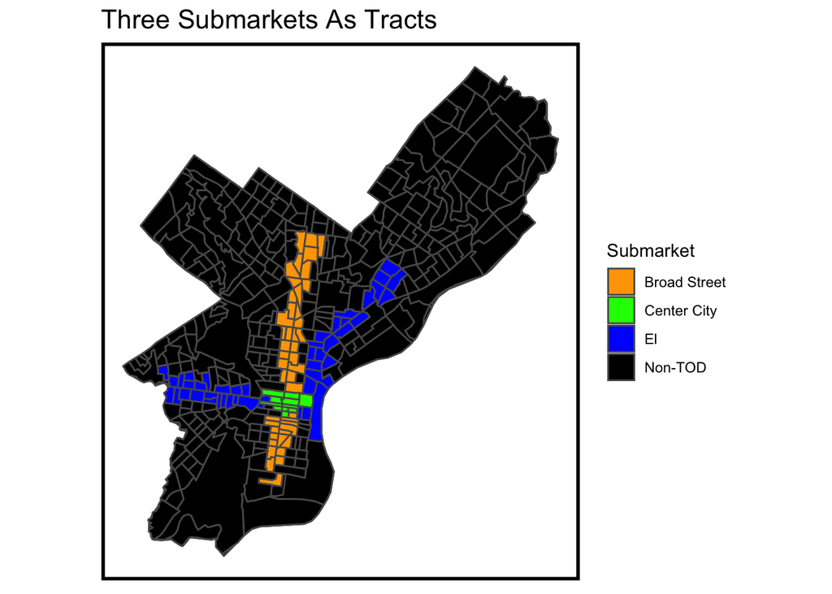

```r
ggplot(allTracts.threeMarkets)+
  geom_sf(data = st_union(tracts09))+
  geom_sf(aes(fill = Submarket))+
  scale_fill_manual(values = c("orange", "green", "blue", "black"))+
  labs(title = "Three Submarkets As Tracts") +
  mapTheme()
```

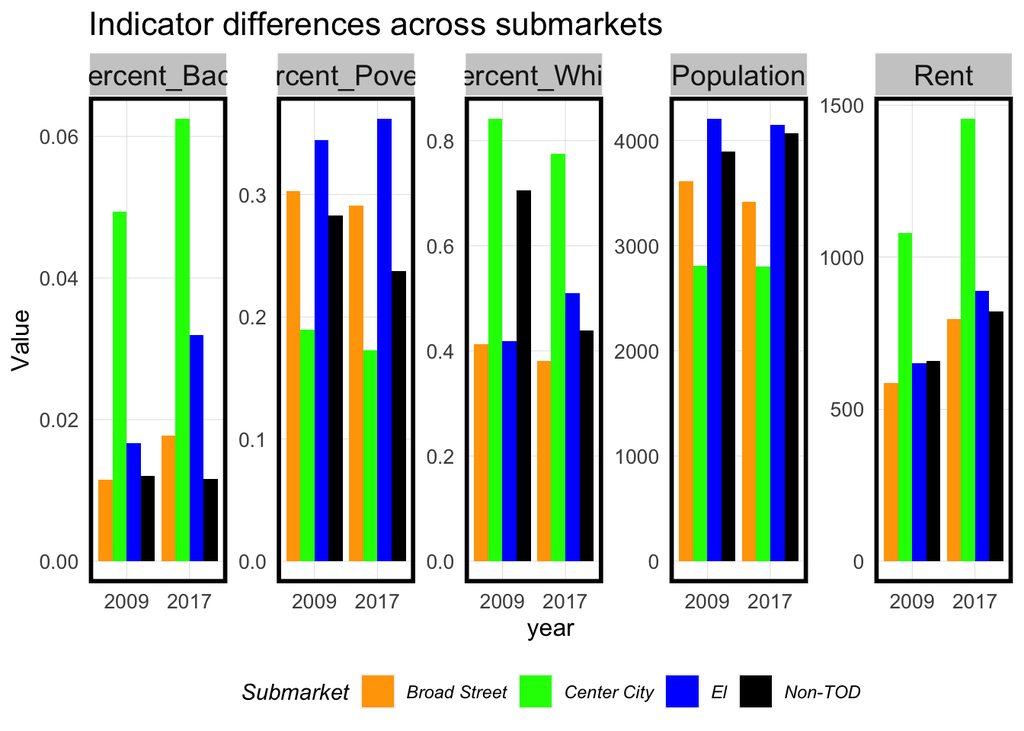

```r
st_drop_geometry(allTracts.threeMarkets) %>%
  group_by(year, Submarket) %>%
  summarize(Rent = mean(MedRent, na.rm = T),
            Population = mean(TotalPop, na.rm = T),
            Percent_White = mean(pctWhite, na.rm = T),
            Percent_Bach = mean(pctBachelors, na.rm = T),
            Percent_Poverty = mean(pctPoverty, na.rm = T)) %>%
  gather(Variable, Value, -year, -Submarket) %>%
  ggplot(aes(year, Value, fill = Submarket)) +
  geom_bar(stat = "identity", position = "dodge") +
  facet_wrap(~Variable, scales = "free", ncol=5) +
  scale_fill_manual(values = c("orange", "green", "blue", "black"))+
  labs(title = "Indicator differences across submarkets") +
  plotTheme() + theme(legend.position="bottom")
```